# Travel Package Purchase Prediction - Project

# **Context:**

You are a Data Scientist for a tourism company named "Visit with us". The Policy Maker of the company wants to enable and establish a viable business model to expand the customer base.

A viable business model is a central concept that helps you to understand the existing ways of doing the business and how to change the ways for the benefit of the tourism sector.

One of the ways to expand the customer base is to introduce a new offering of packages.

Currently, there are 5 types of packages the company is offering - Basic, Standard, Deluxe, Super Deluxe, King. Looking at the data of the last year, we observed that 18% of the customers purchased the packages.

However, the marketing cost was quite high because customers were contacted at random without looking at the available information.

The company is now planning to launch a new product i.e. Wellness Tourism Package. Wellness Tourism is defined as Travel that allows the traveler to maintain, enhance or kick-start a healthy lifestyle, and support or increase one's sense of well-being.

However, this time company wants to harness the available data of existing and potential customers to make the marketing expenditure more efficient.

You as a Data Scientist at "Visit with us" travel company have to analyze the customers' data and information to provide recommendations to the Policy Maker and Marketing Team and also build a model to predict the potential customer who is going to purchase the newly introduced travel package.

# **Objective:**

To predict which customer is more likely to purchase the newly introduced travel package.

# **Data Dictionary**

## **Customer details:**

- CustomerID: Unique customer ID
- ProdTaken: Product taken flag
- Age: Age of customer
- TypeofContact: How customer was contacted (Company Invited or Self Inquiry)
- CityTier: City tier
- Occupation: Occupation of customer
- Gender: Gender of customer
- NumberOfPersonVisited: Total number of person came with customer
- PreferredPropertyStar: Preferred hotel property rating by customer
- MaritalStatus: Marital status of customer
- NumberOfTrips: Average number of the trip in a year by customer
- Passport: The customer has passport or not
- OwnCar: Customers owns a car flag
- NumberOfChildrenVisited: Total number of children with age less than 5 visit with customer
- Designation: Designation of the customer in the current organization
- MonthlyIncome: Gross monthly income of the customer

## **Customer interaction data:**

- PitchSatisfactionScore: Sales pitch satisfactory score
- ProductPitched: Product pitched by a salesperson
- NumberOfFollowups: Total number of follow up has been done by sales person after sales pitch
- DurationOfPitch: Duration of the pitch by a salesman to customer

### Overview of the dataset

```python
import warnings
warnings.filterwarnings("ignore")

import numpy as np
import pandas as pd
import seaborn as sns
import matplotlib.pyplot as plt
from sklearn import metrics
from sklearn.model_selection import GridSearchCV,train_test_split
from sklearn.tree import DecisionTreeClassifier
from sklearn.ensemble import BaggingClassifier
from sklearn.ensemble import RandomForestClassifier
from sklearn.ensemble import StackingClassifier
from sklearn.ensemble import AdaBoostClassifier, GradientBoostingClassifier
from xgboost import XGBClassifier
```

#### Loading Data

```python
data = pd.read_excel('Tourism.xlsx','Tourism')
# print first 5 rows of the dataset
data.head()
```

|  | CustomerID | ProdTaken | Age | TypeofContact | CityTier | DurationOfPitch | Occupation | Gender | NumberOfPersonVisited | NumberOfFollowups | ProductPitched | PreferredPropertyStar | MaritalStatus | NumberOfTrips | Passport | PitchSatisfactionScore | OwnCar | NumberOfChildrenVisited | Designation | MonthlyIncome |
| --- | --- | --- | --- | --- | --- | --- | --- | --- | --- | --- | --- | --- | --- | --- | --- | --- | --- | --- | --- | --- |
| 0 | 200000 | 1 | 41.0 | Self Enquiry | 3 | 6.0 | Salaried | Female | 3 | 3.0 | Deluxe | 3.0 | Single | 1.0 | 1 | 2 | 1 | 0.0 | Manager | 20993.0 |
| 1 | 200001 | 0 | 49.0 | Company Invited | 1 | 14.0 | Salaried | Male | 3 | 4.0 | Deluxe | 4.0 | Divorced | 2.0 | 0 | 3 | 1 | 2.0 | Manager | 20130.0 |
| 2 | 200002 | 1 | 37.0 | Self Enquiry | 1 | 8.0 | Free Lancer | Male | 3 | 4.0 | Basic | 3.0 | Single | 7.0 | 1 | 3 | 0 | 0.0 | Executive | 17090.0 |
| 3 | 200003 | 0 | 33.0 | Company Invited | 1 | 9.0 | Salaried | Female | 2 | 3.0 | Basic | 3.0 | Divorced | 2.0 | 1 | 5 | 1 | 1.0 | Executive | 17909.0 |
| 4 | 200004 | 0 | NaN | Self Enquiry | 1 | 8.0 | Small Business | Male | 2 | 3.0 | Basic | 4.0 | Divorced | 1.0 | 0 | 5 | 1 | 0.0 | Executive | 18468.0 |

#### Check datatypes and missing values of each columns

```python
data.info()
```

```
<class 'pandas.core.frame.DataFrame'>
RangeIndex: 4888 entries, 0 to 4887
Data columns (total 20 columns):
 #   Column                   Non-Null Count  Dtype
---  ------                   --------------  -----
 0   CustomerID               4888 non-null   int64
 1   ProdTaken                4888 non-null   int64
 2   Age                      4662 non-null   float64
 3   TypeofContact            4863 non-null   object
 4   CityTier                 4888 non-null   int64
 5   DurationOfPitch          4637 non-null   float64
 6   Occupation               4888 non-null   object
 7   Gender                   4888 non-null   object
 8   NumberOfPersonVisited    4888 non-null   int64
 9   NumberOfFollowups        4843 non-null   float64
 10  ProductPitched           4888 non-null   object
 11  PreferredPropertyStar    4862 non-null   float64
 12  MaritalStatus            4888 non-null   object
 13  NumberOfTrips            4748 non-null   float64
 14  Passport                 4888 non-null   int64
 15  PitchSatisfactionScore   4888 non-null   int64
 16  OwnCar                   4888 non-null   int64
 17  NumberOfChildrenVisited  4822 non-null   float64
 18  Designation              4888 non-null   object
 19  MonthlyIncome            4655 non-null   float64
dtypes: float64(7), int64(7), object(6)
memory usage: 763.9+ KB
```

- As we can see, there are 20 columns and 4,888 rows based on CustomerID (unique values of each rows)
- There are also null values of some columns (Age, TypeofContact, DurationOfPitch, NumberOfFollowups, PreferredPropertyStar, NumberOfTrips, NumberOfChildrenVisited, MonthlyIncome)
- Dataset has 3 type of data ( int, float and Object )
- Object type columns(TypeofContact,Occupation,Gender,ProductPitched,MaritalStatus,Designation) need to convert to cateogrical variable.

```python
# convert object columns to categorical variable
object_cols = ['TypeofContact','Occupation','Gender','ProductPitched','MaritalStatus','Designation']
for column in object_cols:
    data[column] = data[column].astype("category")
```

```python
data.info()
```

```
<class 'pandas.core.frame.DataFrame'>
RangeIndex: 4888 entries, 0 to 4887
Data columns (total 20 columns):
 #   Column                   Non-Null Count  Dtype
---  ------                   --------------  -----
 0   CustomerID               4888 non-null   int64
 1   ProdTaken                4888 non-null   int64
 2   Age                      4662 non-null   float64
 3   TypeofContact            4863 non-null   category
 4   CityTier                 4888 non-null   int64
 5   DurationOfPitch          4637 non-null   float64
 6   Occupation               4888 non-null   category
 7   Gender                   4888 non-null   category
 8   NumberOfPersonVisited    4888 non-null   int64
 9   NumberOfFollowups        4843 non-null   float64
 10  ProductPitched           4888 non-null   category
 11  PreferredPropertyStar    4862 non-null   float64
 12  MaritalStatus            4888 non-null   category
 13  NumberOfTrips            4748 non-null   float64
 14  Passport                 4888 non-null   int64
 15  PitchSatisfactionScore   4888 non-null   int64
 16  OwnCar                   4888 non-null   int64
 17  NumberOfChildrenVisited  4822 non-null   float64
 18  Designation              4888 non-null   category
 19  MonthlyIncome            4655 non-null   float64
dtypes: category(6), float64(7), int64(7)
memory usage: 564.4 KB
```

#### Check null value

```python
data.isnull().sum()
```

```
CustomerID                   0
ProdTaken                    0
Age                        226
TypeofContact               25
CityTier                     0
DurationOfPitch            251
Occupation                   0
Gender                       0
NumberOfPersonVisited        0
NumberOfFollowups           45
ProductPitched               0
PreferredPropertyStar       26
MaritalStatus                0
NumberOfTrips              140
Passport                     0
PitchSatisfactionScore       0
OwnCar                       0
NumberOfChildrenVisited     66
Designation                  0
MonthlyIncome              233
dtype: int64
```

- DurationOfPitch: has the most missing values 251
- TypeofContact: has less missing values 25

#### Summary of dataset

```python
data.describe().T
```

|  | count | mean | std | min | 25% | 50% | 75% | max |
| --- | --- | --- | --- | --- | --- | --- | --- | --- |
| CustomerID | 4888.0 | 202443.500000 | 1411.188388 | 200000.0 | 201221.75 | 202443.5 | 203665.25 | 204887.0 |
| ProdTaken | 4888.0 | 0.188216 | 0.390925 | 0.0 | 0.00 | 0.0 | 0.00 | 1.0 |
| Age | 4662.0 | 37.622265 | 9.316387 | 18.0 | 31.00 | 36.0 | 44.00 | 61.0 |
| CityTier | 4888.0 | 1.654255 | 0.916583 | 1.0 | 1.00 | 1.0 | 3.00 | 3.0 |
| DurationOfPitch | 4637.0 | 15.490835 | 8.519643 | 5.0 | 9.00 | 13.0 | 20.00 | 127.0 |
| NumberOfPersonVisited | 4888.0 | 2.905074 | 0.724891 | 1.0 | 2.00 | 3.0 | 3.00 | 5.0 |
| NumberOfFollowups | 4843.0 | 3.708445 | 1.002509 | 1.0 | 3.00 | 4.0 | 4.00 | 6.0 |
| PreferredPropertyStar | 4862.0 | 3.581037 | 0.798009 | 3.0 | 3.00 | 3.0 | 4.00 | 5.0 |
| NumberOfTrips | 4748.0 | 3.236521 | 1.849019 | 1.0 | 2.00 | 3.0 | 4.00 | 22.0 |
| Passport | 4888.0 | 0.290917 | 0.454232 | 0.0 | 0.00 | 0.0 | 1.00 | 1.0 |
| PitchSatisfactionScore | 4888.0 | 3.078151 | 1.365792 | 1.0 | 2.00 | 3.0 | 4.00 | 5.0 |
| OwnCar | 4888.0 | 0.620295 | 0.485363 | 0.0 | 0.00 | 1.0 | 1.00 | 1.0 |
| NumberOfChildrenVisited | 4822.0 | 1.187267 | 0.857861 | 0.0 | 1.00 | 1.0 | 2.00 | 3.0 |
| MonthlyIncome | 4655.0 | 23619.853491 | 5380.698361 | 1000.0 | 20346.00 | 22347.0 | 25571.00 | 98678.0 |

- Based on 5 points summary report, we also can confirm that there are missing values in dataset.
- The min monthlyIncome is 1,000.0 and Max is 98,678.0 and some recording or observation are missing value.
- Age of customer min is 18 and Max is 61 years old.

#### number of unique value each columns

```python
data.nunique()
```

```
CustomerID                 4888
ProdTaken                     2
Age                          44
TypeofContact                 2
CityTier                      3
DurationOfPitch              34
Occupation                    4
Gender                        3
NumberOfPersonVisited         5
NumberOfFollowups             6
ProductPitched                5
PreferredPropertyStar         3
MaritalStatus                 4
NumberOfTrips                12
Passport                      2
PitchSatisfactionScore        5
OwnCar                        2
NumberOfChildrenVisited       4
Designation                   5
MonthlyIncome              2475
dtype: int64
```

- We can drop "CustomerID" since it just increase number and will not add any value to the model.
- "Occupation" and "Designation" might need to drop either one of them because they are not much different.
- "NumberOfChildrenVisited" might need to drop as well because we have "NumberOfPersonVisited" should be good enough for the model.

##### drop columns

```python
data.drop(columns=['CustomerID','Designation'], inplace=True)
```

#### Check the count of each categorical columns

```python
cat_columns = ['TypeofContact', 'CityTier', 'Occupation', 'Gender', 'ProductPitched','PreferredPropertyStar','MaritalStatus','Passport','PitchSatisfactionScore','OwnCar']
for column in cat_columns:
    print(data[column].value_counts())
    print('-'*50)
```

```
Self Enquiry       3444
Company Invited    1419
Name: TypeofContact, dtype: int64
--------------------------------------------------
1    3190
3    1500
2     198
Name: CityTier, dtype: int64
--------------------------------------------------
Salaried          2368
Small Business    2084
Large Business     434
Free Lancer          2
Name: Occupation, dtype: int64
--------------------------------------------------
Male       2916
Female     1817
Fe Male     155
Name: Gender, dtype: int64
--------------------------------------------------
Basic           1842
Deluxe          1732
Standard         742
Super Deluxe     342
King             230
Name: ProductPitched, dtype: int64
--------------------------------------------------
3.0    2993
5.0     956
4.0     913
Name: PreferredPropertyStar, dtype: int64
--------------------------------------------------
Married      2340
Divorced      950
Single        916
Unmarried     682
Name: MaritalStatus, dtype: int64
--------------------------------------------------
0    3466
1    1422
Name: Passport, dtype: int64
--------------------------------------------------
3    1478
5     970
1     942
4     912
2     586
Name: PitchSatisfactionScore, dtype: int64
--------------------------------------------------
1    3032
0    1856
Name: OwnCar, dtype: int64
--------------------------------------------------
```

- "Gender" column has wrong data (typo "Fe Male"). We need to replace with correct "Female".
- "Occupation" column only 2 rows are Free Lancer, it is very less than other values.
- Most customers are owning car 1: 3032 observations.

#### Correct the typo "Fe Male" to "Female"

```python
data.loc[data['Gender']=="Fe Male", "Gender"] = "Female"
```

```python
data[data['Gender']=="Fe Male"]
```

|  | ProdTaken | Age | TypeofContact | CityTier | DurationOfPitch | Occupation | Gender | NumberOfPersonVisited | NumberOfFollowups | ProductPitched | PreferredPropertyStar | MaritalStatus | NumberOfTrips | Passport | PitchSatisfactionScore | OwnCar | NumberOfChildrenVisited | MonthlyIncome |
| --- | --- | --- | --- | --- | --- | --- | --- | --- | --- | --- | --- | --- | --- | --- | --- | --- | --- | --- |

- No more "Fe Male" values in the dataset.

#### Treat the missing values by replacing Median for the continuous variables and Mode for the categorical variables

```python
continuous_cols = ['Age','DurationOfPitch','NumberOfFollowups','NumberOfTrips','MonthlyIncome','NumberOfChildrenVisited']
for column in continuous_cols:
    data[column] = data[column].fillna(data[column].median())
```

```python
cat_cols = ['TypeofContact','PreferredPropertyStar']
for column in cat_cols:
    data[column] = data[column].fillna(data[column].mode()[0])
```

```python
data.isnull().sum()
```

```
ProdTaken                  0
Age                        0
TypeofContact              0
CityTier                   0
DurationOfPitch            0
Occupation                 0
Gender                     0
NumberOfPersonVisited      0
NumberOfFollowups          0
ProductPitched             0
PreferredPropertyStar      0
MaritalStatus              0
NumberOfTrips              0
Passport                   0
PitchSatisfactionScore     0
OwnCar                     0
NumberOfChildrenVisited    0
MonthlyIncome              0
dtype: int64
```

### EDA

#### Univariate analysis

```python
# While doing uni-variate analysis of numerical variables we want to study their central tendency
# and dispersion.
# Let us write a function that will help us create boxplot and histogram for any input numerical
# variable.
# This function takes the numerical column as the input and returns the boxplots
# and histograms for the variable.

def histogram_boxplot(feature, figsize=(15,10), bins = None):
    """ Boxplot and histogram combined
    feature: 1-d feature array
    figsize: size of fig (default (9,8))
    bins: number of bins (default None / auto)
    """
    f2, (ax_box2, ax_hist2) = plt.subplots(nrows = 2, # Number of rows of the subplot grid= 2
                                           sharex = True, # x-axis will be shared among all subplots
                                           gridspec_kw = {"height_ratios": (.25, .75)},
                                           figsize = figsize
                                           ) # creating the 2 subplots
    sns.boxplot(feature, ax=ax_box2, showmeans=True, color='violet') # boxplot will be created and a star will indicate the mean value of the column
    sns.distplot(feature, kde=F, ax=ax_hist2, bins=bins,palette="winter") if bins else sns.distplot(feature, kde=False, ax=ax_hist2) # For histogram
    ax_hist2.axvline(np.mean(feature), color='green', linestyle='--') # Add mean to the histogram
    ax_hist2.axvline(np.median(feature), color='black', linestyle='-') # Add median to the histogram
```

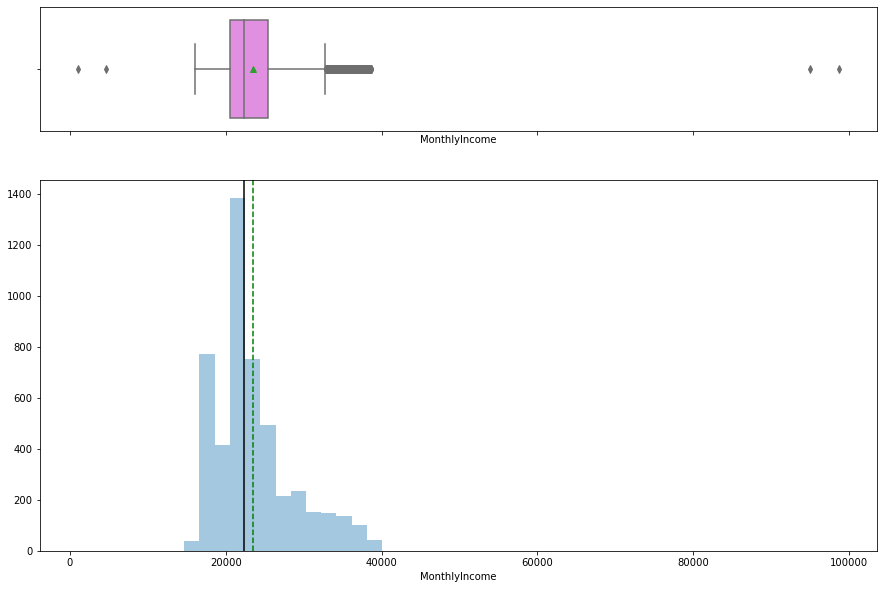

```python
histogram_boxplot(data['MonthlyIncome'])
```

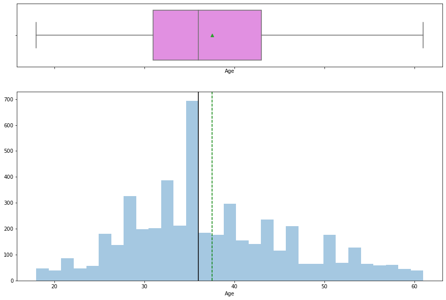

```python
histogram_boxplot(data['Age'])
```

```python
#Function to create barplots that indicate percentage for each category
def perc_on_bar(feature):
    '''
    plot
    feature: categorical feature
    the function won't work if a column is passed in hue parameter
    '''
    #Creating a countplot for the feature
    sns.set(rc={'figure.figsize':(15,7)})
    ax=sns.countplot(x=feature, data=data)

    total = len(feature) # length of the column
    for p in ax.patches:
        percentage = '{:.1f}%'.format(100 * p.get_height()/total) # percentage of each class of the category
        x = p.get_x() + p.get_width() / 2 - 0.25 # width of the plot
        y = p.get_y() + p.get_height()           # hieght of the plot
        ax.annotate(percentage, (x, y), size = 14) # annotate the percantage

    plt.show() # show the plot
```

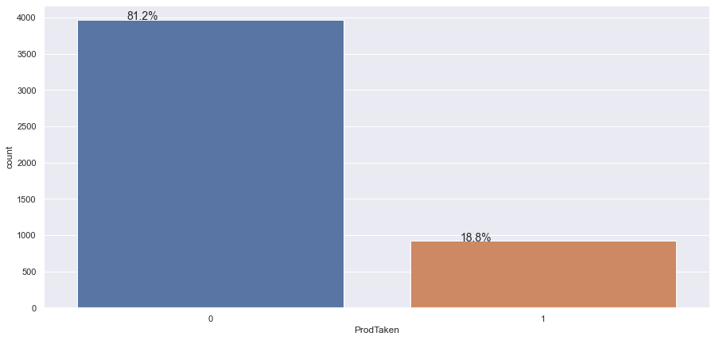

```python
perc_on_bar(data['ProdTaken'])
```

- Ony 18.8% of customers purchased the packages and 81.2% did not

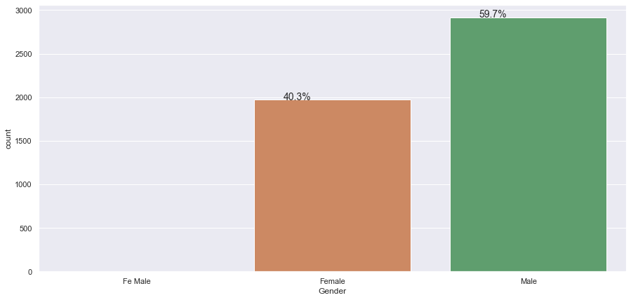

```python
perc_on_bar(data['Gender'])
```

- 59.7% of the customers are Male and 40.35 are Female

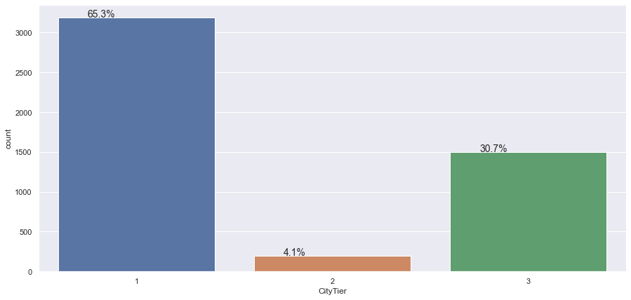

```python
perc_on_bar(data['CityTier'])
```

- Only 4.1% of the customers in CityTier 2

#### Bivariate analysis

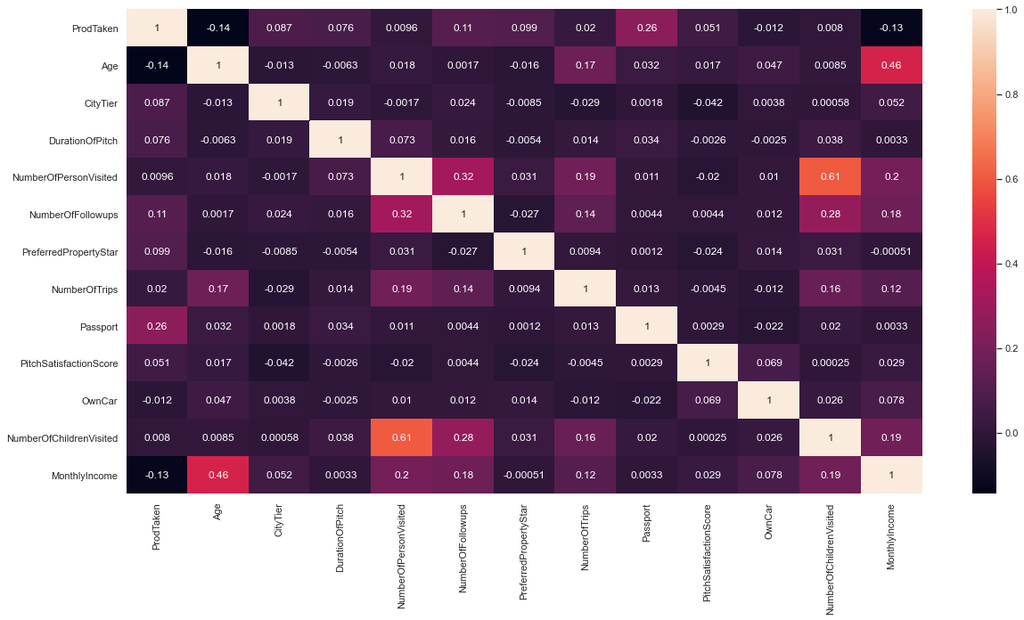

```python
plt.figure(figsize=(20,10))
sns.heatmap(data.corr(),annot=True)
plt.show()
```

```python
data
```

|  | ProdTaken | Age | TypeofContact | CityTier | DurationOfPitch | Occupation | Gender | NumberOfPersonVisited | NumberOfFollowups | ProductPitched | PreferredPropertyStar | MaritalStatus | NumberOfTrips | Passport | PitchSatisfactionScore | OwnCar | NumberOfChildrenVisited | MonthlyIncome |
| --- | --- | --- | --- | --- | --- | --- | --- | --- | --- | --- | --- | --- | --- | --- | --- | --- | --- | --- |
| 0 | 1 | 41.0 | Self Enquiry | 3 | 6.0 | Salaried | Female | 3 | 3.0 | Deluxe | 3.0 | Single | 1.0 | 1 | 2 | 1 | 0.0 | 20993.0 |
| 1 | 0 | 49.0 | Company Invited | 1 | 14.0 | Salaried | Male | 3 | 4.0 | Deluxe | 4.0 | Divorced | 2.0 | 0 | 3 | 1 | 2.0 | 20130.0 |
| 2 | 1 | 37.0 | Self Enquiry | 1 | 8.0 | Free Lancer | Male | 3 | 4.0 | Basic | 3.0 | Single | 7.0 | 1 | 3 | 0 | 0.0 | 17090.0 |
| 3 | 0 | 33.0 | Company Invited | 1 | 9.0 | Salaried | Female | 2 | 3.0 | Basic | 3.0 | Divorced | 2.0 | 1 | 5 | 1 | 1.0 | 17909.0 |
| 4 | 0 | 36.0 | Self Enquiry | 1 | 8.0 | Small Business | Male | 2 | 3.0 | Basic | 4.0 | Divorced | 1.0 | 0 | 5 | 1 | 0.0 | 18468.0 |
| ... | ... | ... | ... | ... | ... | ... | ... | ... | ... | ... | ... | ... | ... | ... | ... | ... | ... | ... |
| 4883 | 1 | 49.0 | Self Enquiry | 3 | 9.0 | Small Business | Male | 3 | 5.0 | Deluxe | 4.0 | Unmarried | 2.0 | 1 | 1 | 1 | 1.0 | 26576.0 |
| 4884 | 1 | 28.0 | Company Invited | 1 | 31.0 | Salaried | Male | 4 | 5.0 | Basic | 3.0 | Single | 3.0 | 1 | 3 | 1 | 2.0 | 21212.0 |
| 4885 | 1 | 52.0 | Self Enquiry | 3 | 17.0 | Salaried | Female | 4 | 4.0 | Standard | 4.0 | Married | 7.0 | 0 | 1 | 1 | 3.0 | 31820.0 |
| 4886 | 1 | 19.0 | Self Enquiry | 3 | 16.0 | Small Business | Male | 3 | 4.0 | Basic | 3.0 | Single | 3.0 | 0 | 5 | 0 | 2.0 | 20289.0 |
| 4887 | 1 | 36.0 | Self Enquiry | 1 | 14.0 | Salaried | Male | 4 | 4.0 | Basic | 4.0 | Unmarried | 3.0 | 1 | 3 | 1 | 2.0 | 24041.0 |

4888 rows × 18 columns

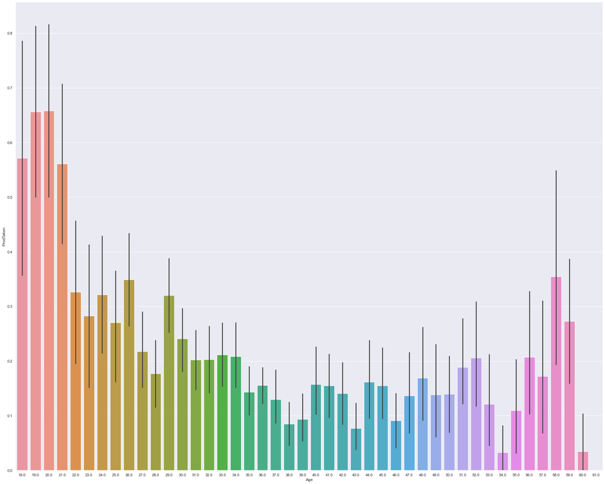

```python
sns.catplot(x="Age", y='ProdTaken', kind='bar', data=data, size=20, aspect=1.25, estimator=np.mean);
```

- As expected, younger people around (18-30) purchased packages more than middle age (30-50), but older people above 55 also purchase packages a lot too.

### Prepare data for modeling

```python
#Dropping columns - NumberOfChildrenVisited and NumberOfPersonVisited
data.drop(columns=['NumberOfChildrenVisited','NumberOfPersonVisited'], inplace=True)
```

```python
data.info()
```

```
<class 'pandas.core.frame.DataFrame'>
RangeIndex: 4888 entries, 0 to 4887
Data columns (total 16 columns):
 #   Column                  Non-Null Count  Dtype
---  ------                  --------------  -----
 0   ProdTaken               4888 non-null   int64
 1   Age                     4888 non-null   float64
 2   TypeofContact           4888 non-null   category
 3   CityTier                4888 non-null   int64
 4   DurationOfPitch         4888 non-null   float64
 5   Occupation              4888 non-null   category
 6   Gender                  4888 non-null   category
 7   NumberOfFollowups       4888 non-null   float64
 8   ProductPitched          4888 non-null   category
 9   PreferredPropertyStar   4888 non-null   float64
 10  MaritalStatus           4888 non-null   category
 11  NumberOfTrips           4888 non-null   float64
 12  Passport                4888 non-null   int64
 13  PitchSatisfactionScore  4888 non-null   int64
 14  OwnCar                  4888 non-null   int64
 15  MonthlyIncome           4888 non-null   float64
dtypes: category(5), float64(6), int64(5)
memory usage: 444.8 KB
```

##### Split the dataset

```python
# Separating features and the target column
X = data.drop('ProdTaken', axis=1)
y = data['ProdTaken']
```

```python
#Convert categorical vriables to dummy variables
X = pd.get_dummies(X, drop_first=True)

#How does drop first help and why we do it
#It reduces the number of columns and hence increases the computational time.
```

```python
#Splitting the data into train and test sets in 70:30 ratio
X_train, X_test, y_train, y_test =train_test_split(X, y, test_size=0.3, random_state=5)
print(X_train.shape, X_test.shape)
```

```
(3421, 23) (1467, 23)
```

### Model building - Bagging

- Build bagging classifier, random forest, and decision tree.
- We are going to build 2 ensemble models here - decision tree, Bagging Classifier and Random Forest Classifier.
- First, let's build these models with default parameters and then use hyperparameter tuning to optimize the model performance.
- We will calculate all three metrics - Accuracy, Precision and Recall but the metric of interest here is recall.
- Recall - It gives the ratio of True positives to Actual positives, so high Recall implies low false negatives.

```python
## Function to create confusion matrix
def make_confusion_matrix(model,y_actual,labels=[1, 0]):
    '''
    model : classifier to predict values of X
    y_actual : ground truth

    '''
    y_predict = model.predict(X_test)
    cm=metrics.confusion_matrix( y_actual, y_predict, labels=[0, 1])
    df_cm = pd.DataFrame(cm, index = [i for i in ["Actual - No","Actual - Yes"]],
                  columns = [i for i in ['Predicted - No','Predicted - Yes']])
    group_counts = ["{0:0.0f}".format(value) for value in
                cm.flatten()]
    group_percentages = ["{0:.2%}".format(value) for value in
                         cm.flatten()/np.sum(cm)]
    labels = [f"{v1}\n{v2}" for v1, v2 in
              zip(group_counts,group_percentages)]
    labels = np.asarray(labels).reshape(2,2)
    plt.figure(figsize = (10,7))
    sns.heatmap(df_cm, annot=labels,fmt='')
    plt.ylabel('True label')
    plt.xlabel('Predicted label')
```

```python
##  Function to calculate different metric scores of the model - Accuracy, Recall and Precision
def get_metrics_score(model,flag=True):
    '''
    model : classifier to predict values of X

    '''
    # defining an empty list to store train and test results
    score_list=[]

    pred_train = model.predict(X_train)
    pred_test = model.predict(X_test)

    train_acc = model.score(X_train,y_train)
    test_acc = model.score(X_test,y_test)

    train_recall = metrics.recall_score(y_train,pred_train)
    test_recall = metrics.recall_score(y_test,pred_test)

    train_precision = metrics.precision_score(y_train,pred_train)
    test_precision = metrics.precision_score(y_test,pred_test)

    score_list.extend((train_acc,test_acc,train_recall,test_recall,train_precision,test_precision))

    # If the flag is set to True then only the following print statements will be dispayed. The default value is set to True.
    if flag == True:
        print("Accuracy on training set : ",model.score(X_train,y_train))
        print("Accuracy on test set : ",model.score(X_test,y_test))
        print("Recall on training set : ",metrics.recall_score(y_train,pred_train))
        print("Recall on test set : ",metrics.recall_score(y_test,pred_test))
        print("Precision on training set : ",metrics.precision_score(y_train,pred_train))
        print("Precision on test set : ",metrics.precision_score(y_test,pred_test))

    return score_list # returning the list with train and test scores
```

##### Decision Tree

- We will build our model using the DecisionTreeClassifier function. Using default 'gini' criteria to split.

```python
decisionTree_model = DecisionTreeClassifier(criterion='gini',class_weight={0:0.15,1:0.85},random_state=1)
decisionTree_model.fit(X_train,y_train)
```

```
DecisionTreeClassifier(class_weight={0: 0.15, 1: 0.85}, random_state=1)
```

```python
#Using above defined function to get accuracy, recall and precision on train and test set
get_metrics_score(decisionTree_model)
```

```
Accuracy on training set :  1.0
Accuracy on test set :  0.8827539195637355
Recall on training set :  1.0
Recall on test set :  0.6764705882352942
Precision on training set :  1.0
Precision on test set :  0.6865671641791045
```

```
[1.0, 0.8827539195637355, 1.0, 0.6764705882352942, 1.0, 0.6865671641791045]
```

- As we can see, this model is overfitting Recall on Training dataset is 1 or 100% and testing dataset only .67 or 67%.
- Let's see if we can reduce overfitting and improve performance on test data by tuning hyperparameters.

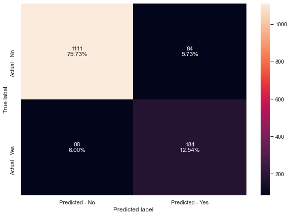

```python
make_confusion_matrix(decisionTree_model,y_test)
```

#### Bagging Classifier

```python
bagging = BaggingClassifier(random_state=1)
bagging.fit(X_train,y_train)
```

```
BaggingClassifier(random_state=1)
```

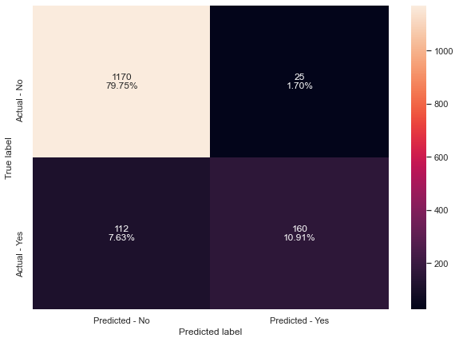

```python
make_confusion_matrix(bagging,y_test)
```

```python
get_metrics_score(bagging)
```

```
Accuracy on training set :  0.9935691318327974
Accuracy on test set :  0.9066121336059987
Recall on training set :  0.9660493827160493
Recall on test set :  0.5882352941176471
Precision on training set :  1.0
Precision on test set :  0.8648648648648649
```

```
[0.9935691318327974,
 0.9066121336059987,
 0.9660493827160493,
 0.5882352941176471,
 1.0,
 0.8648648648648649]
```

- Recall is overfitting 96% in training dataset and only 58% in testing dataset. Accuracy is overfitting.

#### Random Forest

```python
rf = RandomForestClassifier(random_state=1,class_weight='balanced')
rf.fit(X_train,y_train)
```

```
RandomForestClassifier(class_weight='balanced', random_state=1)
```

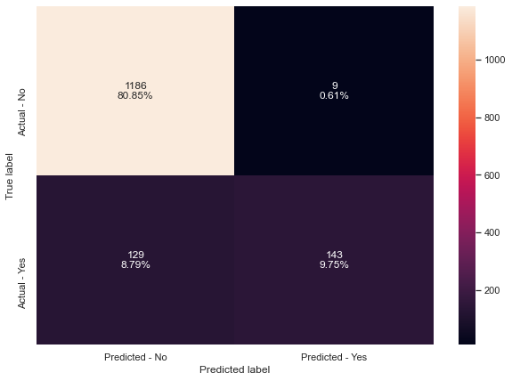

```python
make_confusion_matrix(rf,y_test)
```

```python
get_metrics_score(rf)
```

```
Accuracy on training set :  1.0
Accuracy on test set :  0.9059304703476483
Recall on training set :  1.0
Recall on test set :  0.5257352941176471
Precision on training set :  1.0
Precision on test set :  0.9407894736842105
```

```
[1.0, 0.9059304703476483, 1.0, 0.5257352941176471, 1.0, 0.9407894736842105]
```

- Random Forest, Bagging Classifier, and Decision Tree are overfitting.
- Let's see if we can turn the model by using GridSearch for Hyperparameter tuning model

### Tuning Models

#### Tuning Decision Tree

```python
# Choose the type of classifier.
dtree_estimator = DecisionTreeClassifier(random_state=1,class_weight = {0:.15,1:.85})

# Grid of parameters to choose from
parameters = {
            'max_depth': np.arange(1,10),
            'criterion': ['entropy','gini'],
            'splitter': ['best','random'],
            'min_impurity_decrease': [0.000001,0.00001,0.0001],
            'max_features': ['log2','sqrt']
             }

# Type of scoring used to compare parameter combinations
scorer = metrics.make_scorer(metrics.recall_score)

# Run the grid search
grid_obj = GridSearchCV(dtree_estimator, parameters, scoring=scorer,cv=5)
grid_obj = grid_obj.fit(X_train, y_train)

# Set the clf to the best combination of parameters
dtree_estimator = grid_obj.best_estimator_

# Fit the best algorithm to the data.
dtree_estimator.fit(X_train, y_train)
```

```
DecisionTreeClassifier(class_weight={0: 0.15, 1: 0.85}, criterion='entropy',
                       max_depth=1, max_features='log2',
                       min_impurity_decrease=1e-06, random_state=1,
                       splitter='random')
```

```python
get_metrics_score(dtree_estimator)
```

```
Accuracy on training set :  0.2297573808827828
Accuracy on test set :  0.22085889570552147
Recall on training set :  0.970679012345679
Recall on test set :  0.9963235294117647
Precision on training set :  0.1938366718027735
Precision on test set :  0.19179051663128097
```

```
[0.2297573808827828,
 0.22085889570552147,
 0.970679012345679,
 0.9963235294117647,
 0.1938366718027735,
 0.19179051663128097]
```

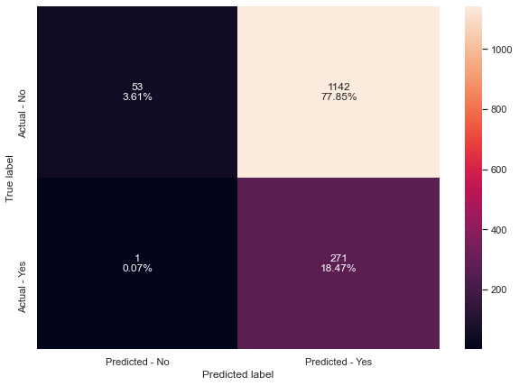

```python
make_confusion_matrix(dtree_estimator,y_test)
```

#### Tuning Bagging Classifier

```python
#grid search for bagging classifier
cl1 = DecisionTreeClassifier(random_state=1)
param_grid = {'base_estimator':[cl1],
              'n_estimators':[5,7,15,51,101],
              'max_features': [0.7,0.8,0.9,1]
             }

grid = GridSearchCV(BaggingClassifier(random_state=1,bootstrap=True), param_grid=param_grid, cv = 5,n_jobs=-1)
grid.fit(X_train, y_train)
```

```
GridSearchCV(cv=5, estimator=BaggingClassifier(random_state=1), n_jobs=-1,
             param_grid={'base_estimator': [DecisionTreeClassifier(random_state=1)],
                         'max_features': [0.7, 0.8, 0.9, 1],
                         'n_estimators': [5, 7, 15, 51, 101]})
```

```python
## getting the best estimator
bagging_estimator  = grid.best_estimator_
bagging_estimator.fit(X_train,y_train)
```

```
BaggingClassifier(base_estimator=DecisionTreeClassifier(random_state=1),
                  max_features=0.9, n_estimators=51, random_state=1)
```

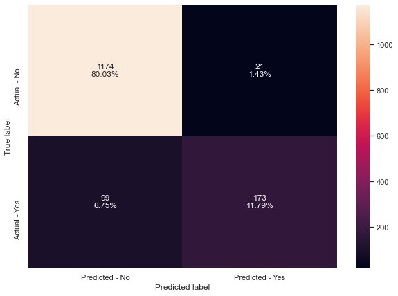

```python
make_confusion_matrix(bagging_estimator,y_test)
```

```python
get_metrics_score(bagging_estimator)
```

```
Accuracy on training set :  0.9997076878105817
Accuracy on test set :  0.918200408997955
Recall on training set :  0.9984567901234568
Recall on test set :  0.6360294117647058
Precision on training set :  1.0
Precision on test set :  0.8917525773195877
```

```
[0.9997076878105817,
 0.918200408997955,
 0.9984567901234568,
 0.6360294117647058,
 1.0,
 0.8917525773195877]
```

- Bagging mode is little better after turning, but still overfitting on Recall.

#### Tuning Random Forest

```python
# Choose the type of classifier.
rf_estimator = RandomForestClassifier(random_state=1,oob_score=True,bootstrap=True)

# Grid of parameters to choose from
parameters = {
                'max_features': ['sqrt','log2','auto'],
                'min_samples_leaf': np.arange(1,15,5),
                'min_samples_split': np.arange(2, 20, 5),
                'n_estimators': list(np.linspace(10, 50, 10, dtype = int))}


# Run the grid search
grid_obj = GridSearchCV(rf_estimator, parameters,cv=5,n_jobs=-1)
grid_obj = grid_obj.fit(X_train, y_train)

# Set the clf to the best combination of parameters
rf_estimator = grid_obj.best_estimator_

# Fit the best algorithm to the data.
rf_estimator.fit(X_train, y_train)
```

```
RandomForestClassifier(max_features='sqrt', n_estimators=41, oob_score=True,
                       random_state=1)
```

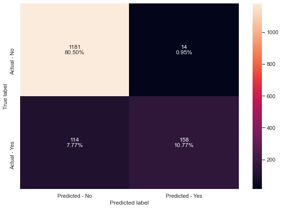

```python
make_confusion_matrix(rf_estimator,y_test)
```

```python
get_metrics_score(rf_estimator)
```

```
Accuracy on training set :  1.0
Accuracy on test set :  0.912747102931152
Recall on training set :  1.0
Recall on test set :  0.5808823529411765
Precision on training set :  1.0
Precision on test set :  0.9186046511627907
```

```
[1.0, 0.912747102931152, 1.0, 0.5808823529411765, 1.0, 0.9186046511627907]
```

- Random forest also still overfitting with Recall. Begging model is a little bettern than Random Forest model.

### Model building - Boosting

- Build Adaboost, gradient boost, xgboost, and stacking classifier

#### AdaBoost Classifier

```python
abc = AdaBoostClassifier(random_state=1)
abc.fit(X_train,y_train)
```

```
AdaBoostClassifier(random_state=1)
```

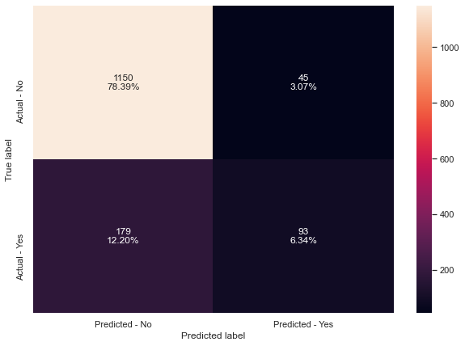

```python
make_confusion_matrix(abc,y_test)
```

```python
get_metrics_score(abc)
```

```
Accuracy on training set :  0.8477053493130664
Accuracy on test set :  0.847307430129516
Recall on training set :  0.3533950617283951
Recall on test set :  0.34191176470588236
Precision on training set :  0.6918429003021148
Precision on test set :  0.6739130434782609
```

```
[0.8477053493130664,
 0.847307430129516,
 0.3533950617283951,
 0.34191176470588236,
 0.6918429003021148,
 0.6739130434782609]
```

- Adaboost classifier is giving a good and no overfitting on train and test. But Recall is low.

#### Gradient Boosting Classifier

```python
gbc = GradientBoostingClassifier(random_state=1)
gbc.fit(X_train,y_train)
```

```
GradientBoostingClassifier(random_state=1)
```

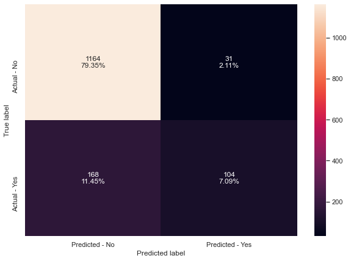

```python
make_confusion_matrix(gbc,y_test)
```

```python
get_metrics_score(gbc)
```

```
Accuracy on training set :  0.8886290558316282
Accuracy on test set :  0.8643490115882754
Recall on training set :  0.470679012345679
Recall on test set :  0.38235294117647056
Precision on training set :  0.8892128279883382
Precision on test set :  0.7703703703703704
```

```
[0.8886290558316282,
 0.8643490115882754,
 0.470679012345679,
 0.38235294117647056,
 0.8892128279883382,
 0.7703703703703704]
```

- based on metric score, this Gradient Boosting model not much different performance to AdaBoosting model.

#### XGBoost Classifier

```python
xgb = XGBClassifier(random_state=1,eval_metric='logloss')
xgb.fit(X_train,y_train)
```

```
XGBClassifier(base_score=0.5, booster='gbtree', colsample_bylevel=1,
              colsample_bynode=1, colsample_bytree=1, eval_metric='logloss',
              gamma=0, gpu_id=-1, importance_type='gain',
              interaction_constraints='', learning_rate=0.300000012,
              max_delta_step=0, max_depth=6, min_child_weight=1, missing=nan,
              monotone_constraints='()', n_estimators=100, n_jobs=8,
              num_parallel_tree=1, random_state=1, reg_alpha=0, reg_lambda=1,
              scale_pos_weight=1, subsample=1, tree_method='exact',
              validate_parameters=1, verbosity=None)
```

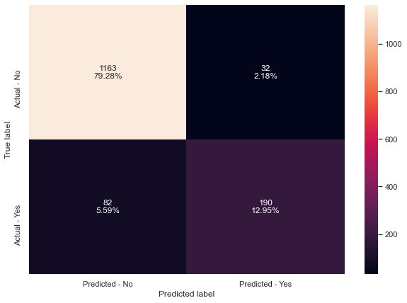

```python
make_confusion_matrix(xgb,y_test)
```

```python
get_metrics_score(xgb)
```

```
Accuracy on training set :  0.9997076878105817
Accuracy on test set :  0.9222903885480572
Recall on training set :  0.9984567901234568
Recall on test set :  0.6985294117647058
Precision on training set :  1.0
Precision on test set :  0.8558558558558559
```

```
[0.9997076878105817,
 0.9222903885480572,
 0.9984567901234568,
 0.6985294117647058,
 1.0,
 0.8558558558558559]
```

- This XGBoost model is overfitting.
- Let's see if we can turn the performance.

### Hyperparameter Tuning

#### AdaBoost Classifier

```python
# Choose the type of classifier.
abc_tuned = AdaBoostClassifier(random_state=1)

# Grid of parameters to choose from
## add from article
parameters = {
    #Let's try different max_depth for base_estimator
    "base_estimator":[DecisionTreeClassifier(max_depth=1),DecisionTreeClassifier(max_depth=2),DecisionTreeClassifier(max_depth=3)],
    "n_estimators": np.arange(10,110,10),
    "learning_rate":np.arange(0.1,1,0.1)
}

# Run the grid search
grid_obj = GridSearchCV(abc_tuned, parameters,cv=5)
grid_obj = grid_obj.fit(X_train, y_train)

# Set the clf to the best combination of parameters
abc_tuned = grid_obj.best_estimator_

# Fit the best algorithm to the data.
abc_tuned.fit(X_train, y_train)
```

```
AdaBoostClassifier(base_estimator=DecisionTreeClassifier(max_depth=3),
                   learning_rate=0.8, n_estimators=100, random_state=1)
```

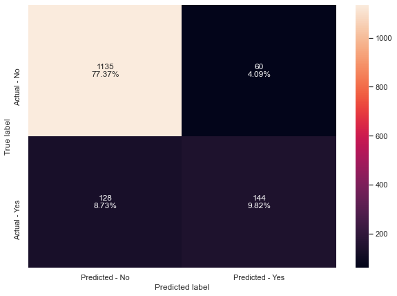

```python
make_confusion_matrix(abc_tuned,y_test)
```

```python
get_metrics_score(abc_tuned)
```

```
Accuracy on training set :  0.9853843905290851
Accuracy on test set :  0.8718473074301295
Recall on training set :  0.9398148148148148
Recall on test set :  0.5294117647058824
Precision on training set :  0.9822580645161291
Precision on test set :  0.7058823529411765
```

```
[0.9853843905290851,
 0.8718473074301295,
 0.9398148148148148,
 0.5294117647058824,
 0.9822580645161291,
 0.7058823529411765]
```

- still overfitting in Recall value

#### Gradient Boosting Classifier

```python
# Choose the type of classifier.
gbc_tuned = GradientBoostingClassifier(init=AdaBoostClassifier(random_state=1),random_state=1)

# Grid of parameters to choose from
## add from article
parameters = {
    "n_estimators": [100,150,200,250],
    "subsample":[0.8,0.9,1],
    "max_features":[0.7,0.8,0.9,1]
}

# Type of scoring used to compare parameter combinations


# Run the grid search
grid_obj = GridSearchCV(gbc_tuned, parameters,cv=5)
grid_obj = grid_obj.fit(X_train, y_train)

# Set the clf to the best combination of parameters
gbc_tuned = grid_obj.best_estimator_

# Fit the best algorithm to the data.
gbc_tuned.fit(X_train, y_train)
```

```
GradientBoostingClassifier(init=AdaBoostClassifier(random_state=1),
                           max_features=0.7, n_estimators=250, random_state=1,
                           subsample=0.8)
```

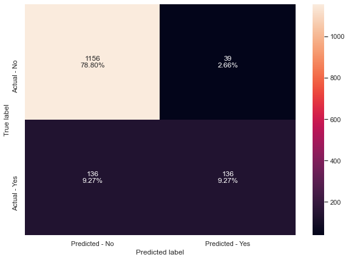

```python
make_confusion_matrix(gbc_tuned,y_test)
```

```python
get_metrics_score(gbc_tuned)
```

```
Accuracy on training set :  0.9213680210464776
Accuracy on test set :  0.8807089297886844
Recall on training set :  0.6296296296296297
Recall on test set :  0.5
Precision on training set :  0.9336384439359268
Precision on test set :  0.7771428571428571
```

```
[0.9213680210464776,
 0.8807089297886844,
 0.6296296296296297,
 0.5,
 0.9336384439359268,
 0.7771428571428571]
```

#### XGBoost Classifier

```python
# Choose the type of classifier.
xgb_tuned = XGBClassifier(random_state=1,eval_metric='logloss')

# Grid of parameters to choose from
## add from
parameters = {
    "n_estimators": np.arange(30,100,20),
    "subsample":[0.5,0.7,1],
    "learning_rate":[0.001,0.01,0.05,0.1],
    "colsample_bytree":[0.5,0.7,1],
    "colsample_bylevel":[0.5,0.7,1]
}

# Type of scoring used to compare parameter combinations

# Run the grid search
grid_obj = GridSearchCV(xgb_tuned, parameters,cv=5)
grid_obj = grid_obj.fit(X_train, y_train)
```

```python
# Set the clf to the best combination of parameters
xgb_tuned = grid_obj.best_estimator_

# Fit the best algorithm to the data.
xgb_tuned.fit(X_train, y_train)
```

```
XGBClassifier(base_score=0.5, booster='gbtree', colsample_bylevel=1,
              colsample_bynode=1, colsample_bytree=1, eval_metric='logloss',
              gamma=0, gpu_id=-1, importance_type='gain',
              interaction_constraints='', learning_rate=0.1, max_delta_step=0,
              max_depth=6, min_child_weight=1, missing=nan,
              monotone_constraints='()', n_estimators=90, n_jobs=8,
              num_parallel_tree=1, random_state=1, reg_alpha=0, reg_lambda=1,
              scale_pos_weight=1, subsample=0.7, tree_method='exact',
              validate_parameters=1, verbosity=None)
```

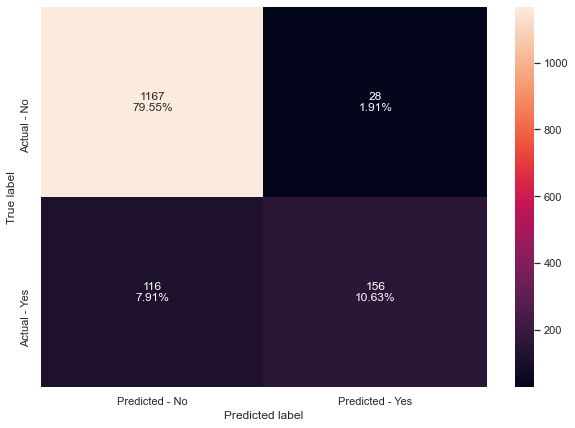

```python
make_confusion_matrix(xgb_tuned,y_test)
```

```python
get_metrics_score(xgb_tuned)
```

```
Accuracy on training set :  0.9660917860274774
Accuracy on test set :  0.901840490797546
Recall on training set :  0.8287037037037037
Recall on test set :  0.5735294117647058
Precision on training set :  0.9907749077490775
Precision on test set :  0.8478260869565217
```

```
[0.9660917860274774,
 0.901840490797546,
 0.8287037037037037,
 0.5735294117647058,
 0.9907749077490775,
 0.8478260869565217]
```

### Stacking Classifier

Now, let's build a stacking model with the tuned models - decision tree, random forest and gradient boosting, then use XGBoost to get the final prediction.

```python
estimators=[('Decision Tree', dtree_estimator),('Random Forest', rf_estimator),
           ('Gradient Boosting', gbc_tuned)]
final_estimator = XGBClassifier(random_state=1,eval_metric='logloss')
```

```python
stacking_estimator=StackingClassifier(estimators=estimators, final_estimator=final_estimator,cv=5)
stacking_estimator.fit(X_train,y_train)
```

```
StackingClassifier(cv=5,
                   estimators=[('Decision Tree',
                                DecisionTreeClassifier(class_weight={0: 0.15,
                                                                     1: 0.85},
                                                       criterion='entropy',
                                                       max_depth=1,
                                                       max_features='log2',
                                                       min_impurity_decrease=1e-06,
                                                       random_state=1,
                                                       splitter='random')),
                               ('Random Forest',
                                RandomForestClassifier(max_features='sqrt',
                                                       n_estimators=41,
                                                       oob_score=True,
                                                       random_state=1)),
                               ('Gradient Boosting',
                                Grad...
                                                 importance_type='gain',
                                                 interaction_constraints=None,
                                                 learning_rate=None,
                                                 max_delta_step=None,
                                                 max_depth=None,
                                                 min_child_weight=None,
                                                 missing=nan,
                                                 monotone_constraints=None,
                                                 n_estimators=100, n_jobs=None,
                                                 num_parallel_tree=None,
                                                 random_state=1, reg_alpha=None,
                                                 reg_lambda=None,
                                                 scale_pos_weight=None,
                                                 subsample=None,
                                                 tree_method=None,
                                                 validate_parameters=None,
                                                 verbosity=None))
```

```python
get_metrics_score(stacking_estimator)
```

```
Accuracy on training set :  0.9991230634317451
Accuracy on test set :  0.9304703476482618
Recall on training set :  1.0
Recall on test set :  0.7573529411764706
Precision on training set :  0.9953917050691244
Precision on test set :  0.8512396694214877
```

```
[0.9991230634317451,
 0.9304703476482618,
 1.0,
 0.7573529411764706,
 0.9953917050691244,
 0.8512396694214877]
```

- Overfitting with Recall value.

### Comparing all models

```python
# defining list of models
models = [decisionTree_model, dtree_estimator,
          bagging, bagging_estimator,
          rf, rf_estimator,
          abc, abc_tuned,
          gbc, gbc_tuned,
          xgb, xgb_tuned,
          stacking_estimator]


# defining empty lists to add train and test results
results = []


# looping through all the models to get the rmse and r2 scores
for model in models:
    result = get_metrics_score(model)
    results.append(result)

df = pd.DataFrame(results, columns=['Accuracy_Train','Accuracy_Test','Recall_Train',
                                    'Recall_Test','Precision_Train','Precision_Test'])
df
```

```
Accuracy on training set :  1.0
Accuracy on test set :  0.8827539195637355
Recall on training set :  1.0
Recall on test set :  0.6764705882352942
Precision on training set :  1.0
Precision on test set :  0.6865671641791045
Accuracy on training set :  0.2297573808827828
Accuracy on test set :  0.22085889570552147
Recall on training set :  0.970679012345679
Recall on test set :  0.9963235294117647
Precision on training set :  0.1938366718027735
Precision on test set :  0.19179051663128097
Accuracy on training set :  0.9935691318327974
Accuracy on test set :  0.9066121336059987
Recall on training set :  0.9660493827160493
Recall on test set :  0.5882352941176471
Precision on training set :  1.0
Precision on test set :  0.8648648648648649
Accuracy on training set :  0.9997076878105817
Accuracy on test set :  0.918200408997955
Recall on training set :  0.9984567901234568
Recall on test set :  0.6360294117647058
Precision on training set :  1.0
Precision on test set :  0.8917525773195877
Accuracy on training set :  1.0
Accuracy on test set :  0.9059304703476483
Recall on training set :  1.0
Recall on test set :  0.5257352941176471
Precision on training set :  1.0
Precision on test set :  0.9407894736842105
Accuracy on training set :  1.0
Accuracy on test set :  0.912747102931152
Recall on training set :  1.0
Recall on test set :  0.5808823529411765
Precision on training set :  1.0
Precision on test set :  0.9186046511627907
Accuracy on training set :  0.8477053493130664
Accuracy on test set :  0.847307430129516
Recall on training set :  0.3533950617283951
Recall on test set :  0.34191176470588236
```

[output cut: 23 more lines]

```
Recall on test set :  0.6985294117647058
Precision on training set :  1.0
Precision on test set :  0.8558558558558559
Accuracy on training set :  0.9660917860274774
Accuracy on test set :  0.901840490797546
Recall on training set :  0.8287037037037037
Recall on test set :  0.5735294117647058
Precision on training set :  0.9907749077490775
Precision on test set :  0.8478260869565217
Accuracy on training set :  0.9991230634317451
Accuracy on test set :  0.9304703476482618
Recall on training set :  1.0
Recall on test set :  0.7573529411764706
Precision on training set :  0.9953917050691244
Precision on test set :  0.8512396694214877
```

|  | Accuracy_Train | Accuracy_Test | Recall_Train | Recall_Test | Precision_Train | Precision_Test |
| --- | --- | --- | --- | --- | --- | --- |
| 0 | 1.000000 | 0.882754 | 1.000000 | 0.676471 | 1.000000 | 0.686567 |
| 1 | 0.229757 | 0.220859 | 0.970679 | 0.996324 | 0.193837 | 0.191791 |
| 2 | 0.993569 | 0.906612 | 0.966049 | 0.588235 | 1.000000 | 0.864865 |
| 3 | 0.999708 | 0.918200 | 0.998457 | 0.636029 | 1.000000 | 0.891753 |
| 4 | 1.000000 | 0.905930 | 1.000000 | 0.525735 | 1.000000 | 0.940789 |
| 5 | 1.000000 | 0.912747 | 1.000000 | 0.580882 | 1.000000 | 0.918605 |
| 6 | 0.847705 | 0.847307 | 0.353395 | 0.341912 | 0.691843 | 0.673913 |
| 7 | 0.985384 | 0.871847 | 0.939815 | 0.529412 | 0.982258 | 0.705882 |
| 8 | 0.888629 | 0.864349 | 0.470679 | 0.382353 | 0.889213 | 0.770370 |
| 9 | 0.921368 | 0.880709 | 0.629630 | 0.500000 | 0.933638 | 0.777143 |
| 10 | 0.999708 | 0.922290 | 0.998457 | 0.698529 | 1.000000 | 0.855856 |
| 11 | 0.966092 | 0.901840 | 0.828704 | 0.573529 | 0.990775 | 0.847826 |
| 12 | 0.999123 | 0.930470 | 1.000000 | 0.757353 | 0.995392 | 0.851240 |

```python
df1 = df.copy()
model_names = ['Decision Tree','Tuned Decision Tree',
               'Bagging','Tuned Bagging',
               'Random Forest', 'Tuned Random Forest',
               'AbaBoosting','Tuned AbaBoosting',
               'Gradient Boosting', 'Tuned Gradient Boosting',
               'XGBoosting', 'Tuned XGBoosting',
               'Stacking Classifier']
df_model_names = pd.DataFrame(model_names, columns=['Model'])
df1 = pd.concat([df1, df_model_names], axis=1)
df1.set_index('Model')
```

| Model | Accuracy_Train | Accuracy_Test | Recall_Train | Recall_Test | Precision_Train | Precision_Test |
| --- | --- | --- | --- | --- | --- | --- |
| Decision Tree | 1.000000 | 0.882754 | 1.000000 | 0.676471 | 1.000000 | 0.686567 |
| Tuned Decision Tree | 0.229757 | 0.220859 | 0.970679 | 0.996324 | 0.193837 | 0.191791 |
| Bagging | 0.993569 | 0.906612 | 0.966049 | 0.588235 | 1.000000 | 0.864865 |
| Tuned Bagging | 0.999708 | 0.918200 | 0.998457 | 0.636029 | 1.000000 | 0.891753 |
| Random Forest | 1.000000 | 0.905930 | 1.000000 | 0.525735 | 1.000000 | 0.940789 |
| Tuned Random Forest | 1.000000 | 0.912747 | 1.000000 | 0.580882 | 1.000000 | 0.918605 |
| AbaBoosting | 0.847705 | 0.847307 | 0.353395 | 0.341912 | 0.691843 | 0.673913 |
| Tuned AbaBoosting | 0.985384 | 0.871847 | 0.939815 | 0.529412 | 0.982258 | 0.705882 |
| Gradient Boosting | 0.888629 | 0.864349 | 0.470679 | 0.382353 | 0.889213 | 0.770370 |
| Tuned Gradient Boosting | 0.921368 | 0.880709 | 0.629630 | 0.500000 | 0.933638 | 0.777143 |
| XGBoosting | 0.999708 | 0.922290 | 0.998457 | 0.698529 | 1.000000 | 0.855856 |
| Tuned XGBoosting | 0.966092 | 0.901840 | 0.828704 | 0.573529 | 0.990775 | 0.847826 |
| Stacking Classifier | 0.999123 | 0.930470 | 1.000000 | 0.757353 | 0.995392 | 0.851240 |

### Feature importance of Tuned XGBoosting Classifier

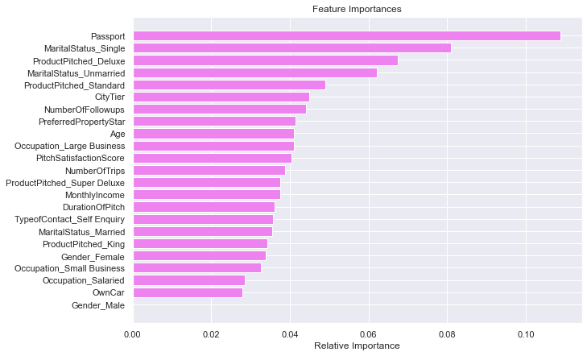

```python
feature_names = X_train.columns
importances = xgb_tuned.feature_importances_
indices = np.argsort(importances)

plt.figure(figsize=(10,7))
plt.title('Feature Importances')
plt.barh(range(len(indices)), importances[indices], color='violet', align='center')
plt.yticks(range(len(indices)), [feature_names[i] for i in indices])
plt.xlabel('Relative Importance')
plt.show()
```

#### Actionable Insights & Recommendations

- Passport, MaritalStatus_Single, and ProductPitched_Deluxe are the top three factors for the customers to purchase package(Wellness Tourism Package)
- As a Data Scientist at "Visit with us", I would recommend the company to promote the new package "Wellness Tourism Package" to customers who have passport, are single or unmarried, Interested with Deluxe and Standard packages.